# GEMMA association, natural hybrids

Marta Binaghi

May 19, 2022

Created: Some time in June 2020 Last modified: 19/05/2022

# 1 Preamble (setup and functions)

```r
library(data.table)
library(ggplot2)
library(scales)
library(reshape2)
library(corrplot)
#library(pscl)
knitr::opts_knit$set(root.dir = "/media/ipsnas/Groups/Deve/Current lab members/marta/hybrids_peaxiINV/")
knitr::opts_chunk$set(root.dir = "/media/ipsnas/Groups/Deve/Current lab members/marta/hybrids_peaxiINV/")
```

# 2 Introduction

Observing distributions of phenotype data of the natural P. ax X P. ex hybrids. Formatting the phenotype data for GWAS with gemma. Observing correlations of phenotype with different variables.

# 3 Phenotype descriptive and correlations

Phenotypes were loaded from the phenotype database that holds per plant mean of the phenotypes. The additional information on plant IDs is taken from the reads sample ID file.

```r
pheno_raw <- read.table("data/clean/phenotype_sequenced_individuals.csv",
                        header = TRUE,
                        sep = ",",
                        stringsAsFactors = FALSE)
# import plant IDs
labels <- read.table("data/clean/reads_sample_ID.csv",
                     sep = ",",
                     header = TRUE,
                     stringsAsFactors = FALSE)
# add a batch column
labels$batch <- 2018
labels$batch[grepl("KMH", labels$sra_library_id)] <- 2016
# remove extra lines that are repeated
labels <- labels[labels$lane == 1, ]
# labels have to be ordered as the beagle likelihood file.
labels <- labels[order(labels$id_gl), ]

pheno_raw$id_gl <- labels$id_gl[match(pheno_raw$new_id_short, labels$new_id_short)]
```

## 3.1 Phenotype distibution

I observe the distribution of the phenotypic traits with a qqplot.

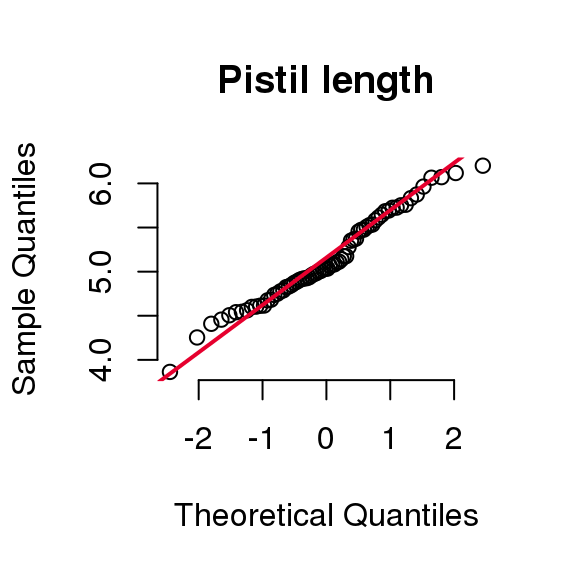

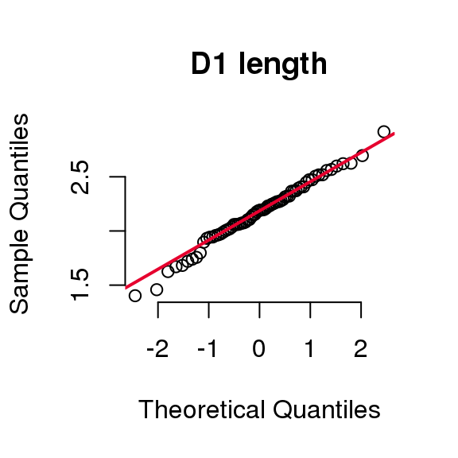

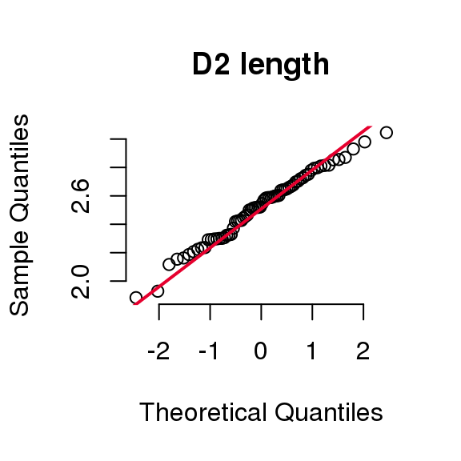

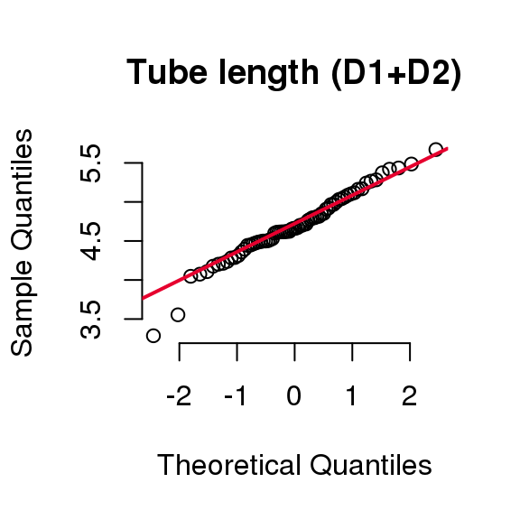

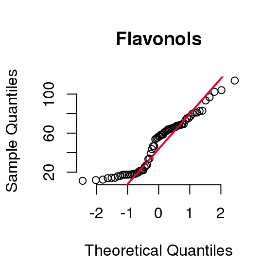

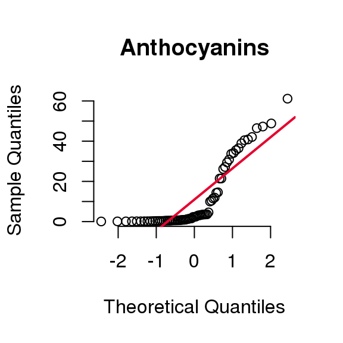

```r
pl <- function(){
  qqnorm(pheno_raw$pist, pch = 1, frame = FALSE, main = "Pistil length")
  qqline(pheno_raw$pist, col = "#e6002e", lwd = 2)
  qqnorm((pheno_raw$D1), pch = 1, frame = FALSE, main ="D1 length")
  qqline((pheno_raw$D1), col = "#e6002e", lwd = 2)
  qqnorm((pheno_raw$D2), pch = 1, frame = FALSE, main = "D2 length")
  qqline((pheno_raw$D2), col = "#e6002e", lwd = 2)
  qqnorm((pheno_raw$Dsum), pch = 1, frame = FALSE, main = "Tube length (D1+D2)")
  qqline((pheno_raw$Dsum), col = "#e6002e", lwd = 2)
  qqnorm((pheno_raw$flav), pch = 1, frame = FALSE, main = "Flavonols")
  qqline((pheno_raw$flav), col = "#e6002e", lwd = 2)
  qqnorm((pheno_raw$antho), pch = 1, frame = FALSE, main = "Anthocyanins")
  qqline((pheno_raw$antho), col = "#e6002e", lwd = 2)
}
pdf("figures/exploratory/gwas/plot_qq_pheno_morpho_gwas.pdf",
    width = 9, height = 6)
par(mfrow = c(2,  3))
pl()
dev.off()
pl()
```

The morphological traits appear normally distributed. The colour-related traits (flavonols and anthocyanins) appear not.

```r
phenos <- c("antho", "flav", "Dsum", "pist")
# output file
outfile <- "data/clean/phenotype_normality.txt"
for (i in phenos) {
  cat("####    ####",
      file = outfile,
      append = TRUE,
      sep = "\n")
  cat(i,
      file = outfile,
      append = TRUE,
      sep = "\n")
  capture.output(shapiro.test(pheno_raw[ , i]),
                 file = outfile,
                 append = TRUE)
}
```

Indeed, the flavonol and anthocyanin are non normally distributed. They are rank-transformed.

```r
pheno_raw$flav_rank <- rank(pheno_raw$flav, na.last = "keep")
pheno_raw$antho_rank <- rank(pheno_raw$antho, na.last = "keep")
```

## 3.2 Phenotype correlation to phenotype

Phenotype to phenotype correlations were tested with Pearson's correlation. Here, I calculate the correlation between pairs of phenotypic traits using Pearson's correlation. I then apply a Bonferroni correction for multiple testing. A correlation matrix showing the Bonferroni-corrected significance is produced.

```r
# #make a column with the location, by extracting it from the original_id
# pheno_raw$location <- gsub(pattern = "(\\w+)_\\d+-\\d+",
#      replacement = "\\1",
#      x = pheno_raw$original_id,
#      perl = TRUE)

# list the variables that I want to have in the correlation matrix
pheno_rawtypes <- c("Dsum", "pist", "flav_rank", "antho_rank")
# make one matrix to keep the correlation estimate value
estimates_mt <- matrix(data = 999, nrow = length(pheno_rawtypes), ncol = length(pheno_rawtypes))
# and one to keep the corresponding P values
pvals_mt <- matrix(data = 999, nrow = length(pheno_rawtypes), ncol = length(pheno_rawtypes))

# loop through the pheno_rawtypes and calculate their correlation with each other
for ( thispheno_raw in pheno_rawtypes ) {
  test <- apply(X = pheno_raw[ , colnames(pheno_raw) %in% pheno_rawtypes],
                MARGIN = 2,
                function(x) cor.test(pheno_raw[ , thispheno_raw], x))
  estimates <- sapply(test, "[[", "estimate")
  pvals <- sapply(test, "[[", "p.value")
  estimates_mt[match(thispheno_raw, pheno_rawtypes), ] <- estimates
  pvals_mt[match(thispheno_raw, pheno_rawtypes), ] <- pvals
}
# name rows and cols of the matrices
colnames(estimates_mt) <- pheno_rawtypes
rownames(estimates_mt) <- pheno_rawtypes
colnames(pvals_mt) <- pheno_rawtypes
rownames(pvals_mt) <- pheno_rawtypes

# apply Bonferroni correction to the P values by multiplying the P values
# by the number of comparisons performed
pvals_bonf_mt <- pvals_mt * ( length(pheno_rawtypes)**2 )

# recode the corrected P values into classes (> 0.05, 0.01-0.05, 0-0.01)
pvals_bonf_class_mt <- pvals_bonf_mt
# recode the classes so they map to meaningful colours in the correlation plot
pvals_bonf_class_mt[pvals_bonf_class_mt >= 0 & pvals_bonf_class_mt < 0.01] <- -1
pvals_bonf_class_mt[pvals_bonf_class_mt >= 0.01 & pvals_bonf_class_mt < 0.05] <- 0
pvals_bonf_class_mt[pvals_bonf_class_mt >= 0.05] <- 1
# make NA the diagonal to avoid plotting self values
diag(pvals_bonf_class_mt) <- NA
# palette
colP <- colorRampPalette(c("#4BA640", "#7ACD70", "#C3C5C3"))
pl <- function(){
  corrplot(estimates_mt, type = "upper", order = "original",
         tl.col = "black", tl.srt = 45,
         tl.pos = "tl",
         method = "color",
         addgrid.col = "white",
         diag = TRUE)
  corrplot(pvals_bonf_class_mt, add = TRUE,
         type = "lower", order = "original",
         tl.col = "black", tl.pos = "n",
         method = "color",
         col = colP(10),
         addgrid.col = "white",
         na.label = " ",
         cl.pos = "n")
}
pdf("figures/exploratory/phenotype/correlogram.pdf", width = 9, height = 9)
pl()
dev.off()
```

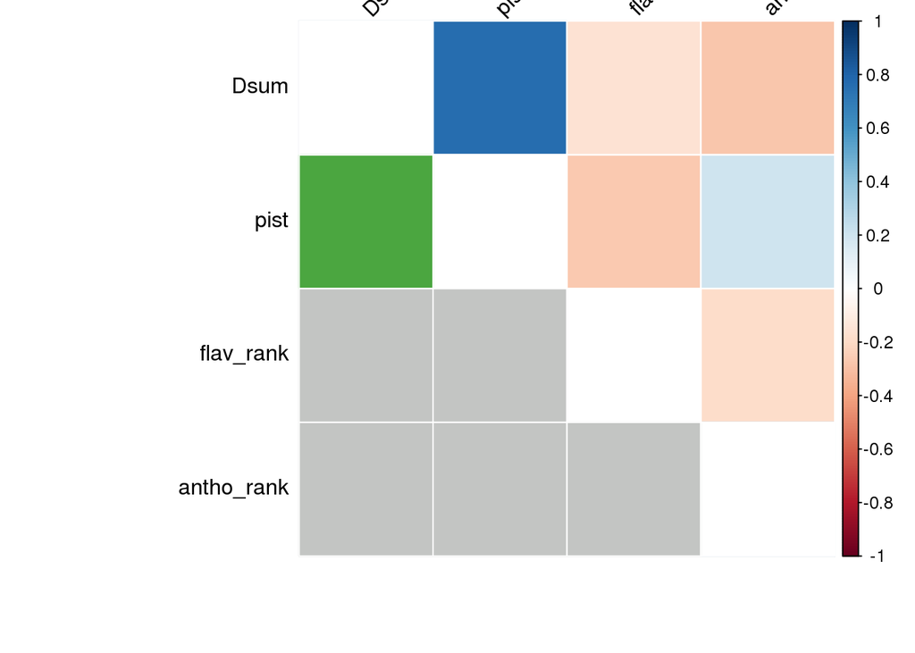

```r
pl()
```

In the correlogram, the lower triangle shows the Bonferroni-corrected significance:

- grey: not significant
- light green: lower than 0.05
- dark green: lower than 0.01

I save the correlation results to a csv file.

```r
# save the results to a readable csv
estimates_mt.long <- melt(estimates_mt)
pvals_mt.long <- melt(pvals_mt)
pvals_bonf_mt.long <- melt(pvals_bonf_mt)
corr_pheno_rawpheno_raw <- merge.data.frame(estimates_mt.long, pvals_mt.long, by = c("Var1", "Var2"))
corr_pheno_rawpheno_raw <- merge.data.frame(corr_pheno_rawpheno_raw, pvals_bonf_mt.long, by = c("Var1", "Var2"))
colnames(corr_pheno_rawpheno_raw) <- c("Variable1", "Variable2", "Pearson_r2", "Pvalue", "Bonferroni_Pvalue")
write.csv(x = corr_pheno_rawpheno_raw,
          file = "data/raw/phenotype/correlation_phenoToPheno.csv",
          quote = FALSE,
          row.names = FALSE)

rm(estimates_mt,
   estimates_mt.long,
   pvals_bonf_class_mt,
   pvals_bonf_mt,
   pvals_bonf_mt.long,
   pvals_mt,
   pvals_mt.long,
   test,
   thispheno_raw,
   pvals,
   estimates,
   colP)
```

## 3.3 Phenotype correlation to principal components

I test phenotype correlation to the first 10 genomic principal components.

```r
# import PCA data
covmat <- read.table("data/raw/pca/cr09_mm005.cov")
# the eigen vector of the covariance matrix:
e <- eigen(covmat)
# the variance explained by each PC:
PCperc <- round(e$values/sum(e$values) * 100, digits = 2)
PCperc[1:10]
```

```
##  [1] 18.83  9.79  7.39  6.44  4.97  4.42  3.68  3.29  2.61  2.48
```

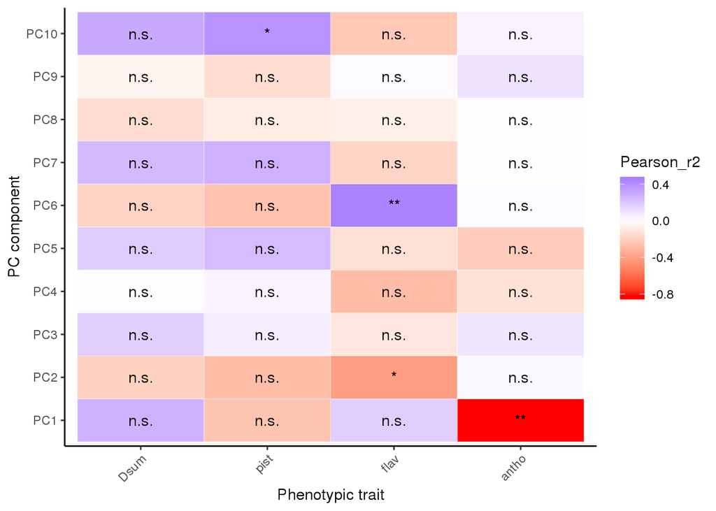

```r
# take first 10 PCs
pcs1.10 <- e$vectors[, 1:10]
# sort pheno df as the PCA
pheno_raw <- pheno_raw[order(pheno_raw$id_gl), ]

# list the variables that I want to have in the correlation matrix
phenotypes <- c("Dsum", "pist",
                "flav", "antho")

# make one matrix to keep the correlation estimate value
estimates_mt <- matrix(data = 999, nrow = length(phenotypes), ncol = 10)
# and one to keep the corresponding P values
pvals_mt <- matrix(data = 999, nrow = length(phenotypes), ncol = 10)

# loop through the phenotypes and calculate their correlation with each PC
for ( thispheno in phenotypes ) {
  test <- apply(X = pcs1.10,
                MARGIN = 2,
                function(x) cor.test(as.numeric(pheno_raw[ , thispheno]), x))
  estimates <- sapply(test, "[[", "estimate")
  pvals <- sapply(test, "[[", "p.value")
  estimates_mt[match(thispheno, phenotypes), ] <- estimates
  pvals_mt[match(thispheno, phenotypes), ] <- pvals
}
# name rows and cols of the matrices
colnames(estimates_mt) <- paste0("PC", 1:10)
rownames(estimates_mt) <- phenotypes
colnames(pvals_mt) <- paste0("PC", 1:10)
rownames(pvals_mt) <- phenotypes

# apply Bonferroni correction to the P values by multiplying the P values
# by the number of comparisons performed
pvals_bonf_mt <- pvals_mt * ( length(phenotypes) * 10 )

# make the matrices into a long df
estimates_mt.long <- melt(estimates_mt)
pvals_mt.long <- melt(pvals_mt)
pvals_bonf_mt.long <- melt(pvals_bonf_mt)
corr_PCpheno <- merge.data.frame(estimates_mt.long, pvals_mt.long, by = c("Var1", "Var2"))
corr_PCpheno <- merge.data.frame(corr_PCpheno, pvals_bonf_mt.long, by = c("Var1", "Var2"))
colnames(corr_PCpheno) <- c("Variable1", "Variable2", "Pearson_r2", "Pvalue", "Bonferroni_Pvalue")

# add a column to code significance of Bonferroni corrected P values
corr_PCpheno$bonf_signif <- "na"
corr_PCpheno$bonf_signif[corr_PCpheno$Bonferroni_Pvalue < 0.01] <- "**"
corr_PCpheno$bonf_signif[corr_PCpheno$Bonferroni_Pvalue < 0.05 &
                           corr_PCpheno$Bonferroni_Pvalue >= 0.01 ] <- "*"
corr_PCpheno$bonf_signif[corr_PCpheno$Bonferroni_Pvalue >= 0.05] <- "n.s."

pl <- ggplot(data = corr_PCpheno,
       aes(Variable1, Variable2)) +
  geom_tile(aes(fill = Pearson_r2),
            colour = "white") +        # adds the thin white line bw cells
  scale_fill_gradient2(low = "red", mid = "white", high = "blue") +
  geom_text(aes(label = bonf_signif)) +
  xlab("Phenotypic trait") +
  ylab("PC component") +
  theme_classic() +
  theme(axis.text.x = element_text(angle = 45, vjust = 1, hjust=1))
ggsave("figures/exploratory/phenotype/correlogram_PCTopheno.png",
       plot = pl,
       width = 8, height = 5)
pl
```

```r
# save the results to a readable csv
write.csv(x = corr_PCpheno,
          file = "data/raw/phenotype/correlation_PCPheno.csv",
          quote = FALSE,
          row.names = FALSE)

rm(estimates_mt,
   estimates_mt.long,
   pvals_bonf_mt,
   pvals_bonf_mt.long,
   pvals_mt,
   pvals_mt.long,
   test,
   thispheno,
   pvals,
   estimates)

print("which correlates significantly?")
```

```
## [1] "which correlates significantly?"
```

```r
corr_PCpheno[corr_PCpheno$Bonferroni_Pvalue < 0.05, ]
```

```
##    Variable1 Variable2 Pearson_r2       Pvalue Bonferroni_Pvalue
## 1      antho       PC1 -0.8260165 2.425696e-18      9.702782e-17
## 23      flav       PC2 -0.4169717 3.650272e-04      1.460109e-02
## 27      flav       PC6  0.4471620 1.171694e-04      4.686776e-03
## 32      pist      PC10  0.3860090 9.656606e-04      3.862642e-02
##    bonf_signif
## 1           **
## 23           *
## 27          **
## 32           *
```

Significantly correlated phenotypes are plotted only to file.

```r
# plot them
for (thispheno in corr_PCpheno$Variable1[corr_PCpheno$Bonferroni_Pvalue < 0.05]) {
  for (pc in corr_PCpheno$Variable2[corr_PCpheno$Bonferroni_Pvalue < 0.05 &
                                    corr_PCpheno$Variable1 == thispheno]) {
    r_label <- paste0("r^2 = ", round(corr_PCpheno$Pearson_r2[corr_PCpheno$Variable1 == thispheno &
                                                        corr_PCpheno$Variable2 == pc],
                                      digits = 2))
    p_label <- paste0("P = ", corr_PCpheno$Bonferroni_Pvalue[corr_PCpheno$Variable1 == thispheno &
                                                               corr_PCpheno$Variable2 == pc])
    pc_idx <- as.integer(gsub("PC", "", pc))
    if ( thispheno == "uv_bin" ) {
      ggplot(data = pheno_raw,
             aes(x = pcs1.10[ , pc_idx],
                 y = uv_bin)) +
        geom_boxplot() +
        geom_point(aes(group = uv_bin, fill = uv_bin),
                   position = position_jitterdodge(0.80),
                   alpha = 0.5) +
        xlab(pc) +
        ylab("UV phenotype") +
        theme_classic() +
        annotate(geom = "text", x = Inf, y = 3, label = r_label,
                 vjust = 1, hjust = 3) +
        annotate(geom = "text", x = Inf, y = 3, label = p_label,
                 vjust = 3, hjust = 1)
      ggsave(paste0("figures/exploratory/phenotype/scatter_", pc, "_", thispheno, "_correl.png"),
             width = 5, height = 5)
    } else {
      ggplot(data = pheno_raw,
             aes(x = pcs1.10[ , pc_idx],
                 y = get(thispheno))) +
        geom_point() +
        geom_smooth(method = "lm", formula = y ~ x,
                    se = FALSE,
                    col = "gray",
                    linetype = "dashed") +
        xlab(pc) +
        ylab(thispheno) +
        theme_classic() +
        annotate(geom = "text", x = Inf, y = Inf, label = r_label,
                 vjust = 1, hjust = 3) +
        annotate(geom = "text", x = Inf, y = Inf, label = p_label,
                 vjust = 3, hjust = 1)
      ggsave(paste0("figures/exploratory/phenotype/scatter_", pc, "_", thispheno, "_correl.png"),
             width = 5, height = 5)
    }
  }
}
```

## 3.4 Phenotypic variance explained by each PC

As in Migicowski, I calculate the phenotypic variance explained by each PC as the correlation between the phenotype and each PC.

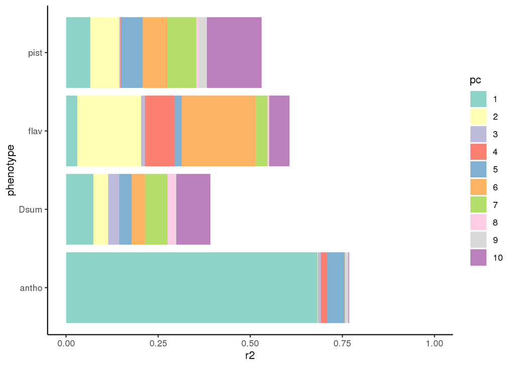

```r
phenotypes <- c("Dsum", "pist",
                "flav", "antho")

# initialise empty df
variance <- data.frame(phenotype = rep(phenotypes, each = 10),
                       pc = 1:10,
                       r2 = NA)

# calculate r^2 using a linear regression for all phenotypes
# for UV binary I use McFadden's pseudo-R2 on a logistic regression

for ( thispheno in phenotypes ) {
  for ( thispc in 1:10 ) {
    if ( thispheno == "uv_bin" ) {
      glm.fit <- glm(pheno_raw$uv_bin ~ pcs1.10[ , thispc], family = "binomial")
      mcf <- pR2(glm.fit)["McFadden"]
      variance$r2[variance$phenotype == thispheno &
                    variance$pc == thispc] <- mcf
    } else {
      lm.fit <- lm(pheno_raw[ , thispheno] ~ pcs1.10[ , thispc])
      variance$r2[variance$phenotype == thispheno &
                    variance$pc == thispc] <- summary(lm.fit)$r.squared
    }
  }
}

# plot
variance$pc <- as.factor(variance$pc)
pl <- ggplot(variance,
       aes(x = phenotype,
           y = r2,
           fill = pc)) +
  geom_bar(position = position_stack(reverse = TRUE),
           stat = "identity") +
  scale_fill_brewer(palette = "Set3") +
  ylim(c(0, 1)) +
  coord_flip() +
  theme_classic()
ggsave("figures/exploratory/phenotype/variance_per_PC.png",
       plot = pl,
       width = 9, height = 6)
pl
```

```r
# save data to a csv
write.csv(variance,
          file = "data/raw/phenotype/phenotypic_variance_by_PC.csv",
          quote = FALSE,
          row.names = FALSE)
```

## 3.5 Correlation admixture location

I also test if a correlation between admixture and location exists.

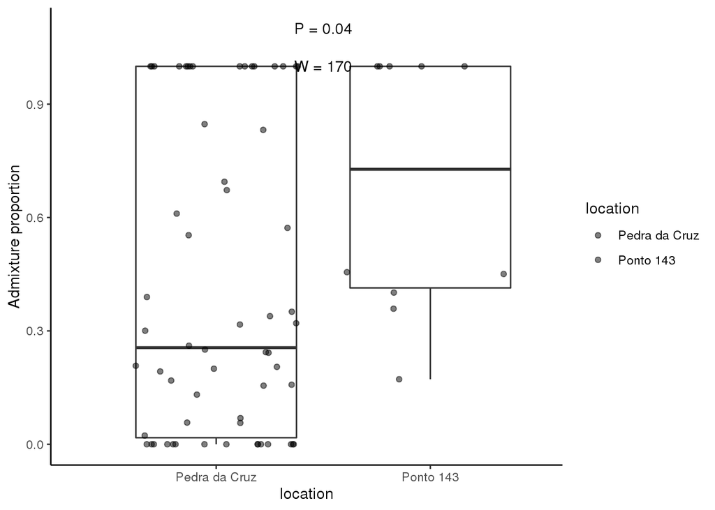

```r
# import admixture data
adm <-read.csv(file = "data/raw/admixture/q2_admixture.csv",
         sep = ",",
         header = TRUE,
          stringsAsFactors = FALSE)
pheno_raw$Q2.1 <- adm$Q2.1[match(pheno_raw$new_id_short, adm$id)]

# get location infor from sample name
pheno_raw$location <- "Pedra da Cruz"
pheno_raw$location[grepl("ponto", pheno_raw$original_id)] <- "Ponto 143"

corr_admLoc <- wilcox.test(pheno_raw$Q2.1 ~ pheno_raw$location)
# plot
pl <- ggplot(data = pheno_raw[ , c("Q2.1", "location")],
       aes(x = location,
           y = Q2.1)) +
  geom_boxplot() +
  geom_point(aes(group = location, fill = location),
             position = position_jitterdodge(0.80),
             alpha = 0.5) +
  ylab("Admixture proportion") +
  theme_classic() +
  annotate(geom = "text", x = 1.5, y = 1.1, label = "P = 0.04") +
  annotate(geom = "text", x = 1.5, y = 1, label = paste0("W = ", corr_admLoc$statistic))
ggsave("figures/exploratory/phenotype/boxplot_correlation_admloc.png",
       plot = pl,
       width = 4,
       height = 5)
pl
```

# 4 Phenotype formatting for GEMMA

## 4.1 Phenotype file format

- Dsum (tube length)
- Pistil length
- Flavonols rank transformed
- Anthocyanins rank transformed

```r
# read order of IDs
id_order <- read.table("data/raw/variants/hardfiltered_biallelic_cr09_mm005.bimbam.ids.txt",
                       header = FALSE)
# sort pheno_raw into id_order
pheno_sorted <- pheno_raw[match(id_order$V1, pheno_raw$new_id_short), ]
# get relevant columns (= phenotypes)
pheno_gwas <- as.data.frame(cbind(pheno_sorted$Dsum,
                    pheno_sorted$pist))
colnames(pheno_gwas) <- c("Dsum", "pist")
# rank transform
pheno_gwas$flav.rank <- rank(pheno_sorted$flav_rank, na.last = "keep")
pheno_gwas$antho.rank <- rank(pheno_sorted$antho_rank, na.last = "keep")
# save phenotype to file
write.table(pheno_gwas,
            file = "data/raw/gwas/pheno_gwas.bimbam",
            sep = " ",
            quote = FALSE,
            row.names = FALSE,
            col.names = FALSE)
```